# Trabalho Final

## Objeto de estudo

## Tema do trabalho

O objetivo deste trabalho é realizar uma análise exploratória sobre a quantidade de linhas de telefonia celular no Brasil (também denominada "Serviço Móvel Pessoal" - SMP) em relação a uma variável econômica (neste caso será utilizado o Produto Interno Bruto - PIB) e uma variável social (usando o Índice de Desenvolvimento Humano - IDH) por Unidade Federativa.

## Dados utilizados

Para análise do objeto em estudo foi realizada a importação dos dados de acesso a linhas de telefonia celular de 10 anos (2005 a 2014) do Portal da Anatel: http://www.anatel.gov.br/dados/destaque-1/283-acessos-smp

Em relação ao PIB e IDH, foram baixados os dados do site do IBGE: https://www.ibge.gov.br/estatisticas-novoportal/economicas/contas-nacionais/9054-contas-regionais-do-brasil.html?=&t=downloads e do Programa das Nações Unidas para o Desenvolvimento (PNUD): http://www.br.undp.org/content/brazil/pt/home/idh0/rankings/idhm-uf-2010.html, respectivamente.

## Objetivo da pesquisa

## Objetivo

Neste trabalho, vamos observar se a tendência de crescimento positivo da telefonia celular possui relação com o crescimento econômico (PIB) ou com a melhora na qualidade de vida da população (IDH). Para isso, utilizaremos o coeficiente de correlação de Pearson (r) para determinar qual é a intensidade da relação que existe entre esses conjuntos de dados.

A correlação linear ou r de Pearson é um grau de relação entre duas variáveis quantitativas e exprime o grau de correlação por meio de valores situados entre -1 e 1.

## PIB e IDH

O Produto Interno Bruto (PIB) foi escolhido para esta análise porque é um dos indicadores mais utilizados na economia de mercado e objetiva examinar as atividades econômicas de um país.

O Índice de Desenvolvimento Humano (IDH) é uma medida resumida do progresso a longo prazo em três dimensões básicas do desenvolvimento humano: renda, educação e saúde. O objetivo da utilização do IDH foi o de oferecer um contraponto ao PIB, que considera apenas a dimensão econômica do desenvolvimento. Desta forma, o IDH é considerado um índice de qualidade de vida, pois sua abordagem de desenvolvimento humano procura olhar diretamente para as pessoas, suas oportunidades e capacidades.

## Método

## Coleta e Organização dos dados

Importação dos dados analisados

```r
# Importação dos dados das linhas de celular
acessos_smp <- read.csv("https://raw.githubusercontent.com/Hkawata1/ENAP_ADPP/master/Acessos_SMP_2005_2014_UF.csv",
                        sep=";", dec=",", header = TRUE)

# Importação dos dados sobre PIB
pib_pop <- read.csv("https://raw.githubusercontent.com/Hkawata1/ENAP_ADPP/master/PIB_Populacao_2010_2014.csv",
                    sep=";", dec=",", header = TRUE)

# Importação dos dados sobre IDH
idh <- read.csv("https://raw.githubusercontent.com/Hkawata1/ENAP_ADPP/master/IDH_2010_UF.csv",
                sep=";", dec=".", header = TRUE, stringsAsFactors = FALSE)
```

## Análise das variáveis

Os dados mais atualizados do Produto Interno Bruto (PIB) por UF datam de 2015, disponibilizados no site do IBGE em 2017.

O Programa das Nações Unidas para o Desenvolvimento (PNUD), o qual divulga o IDH, só possui dados atualizados por UF no Brasil até 2010.

Para a análise de correlação será utilizado o comando cor.test pela conveniência de já considerar um intervalo de confiança de 95%.

## Contextualização

## A telefonia celular no Brasil

A primeira rede de telefonia celular do Brasil foi lançaada pela Telerj, no Rio de Janeiro em 1990. Atualmente no Brasil existem 234 milhões de linhas de telefones celulares ativas (dados da Anatel até agosto de 2018).

A popularização e disseminação das linhas de telefonia celular ocorreu apenas nos anos 2000, com o barateamento de aparelhos, melhoria de funcionalidades e dos sistemas de processamento. O lançamento dos primeiros smartphones (Blackberrys em 2002, Iphones em 2007 e celulares com sistema Android em 2008) incentivou significativamente a aquisição de linhas celulares, conforme pode ser observado no gráfico a seguir.

## Tendência de crescimento da telefonia celular em 10 anos

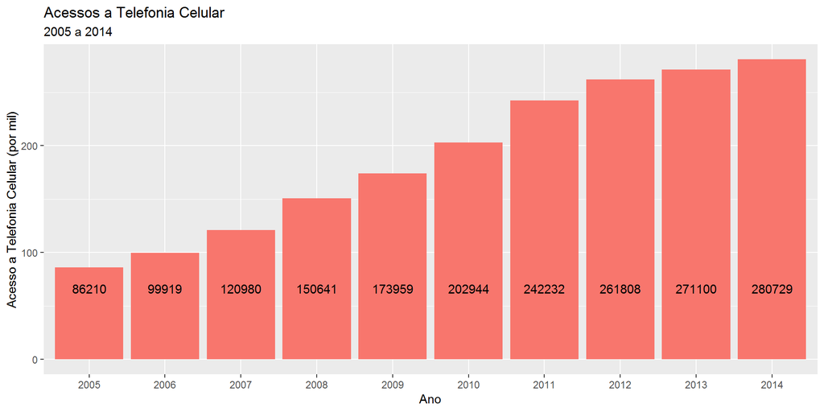

## Cenário da telefonia celular em 2010 por UF

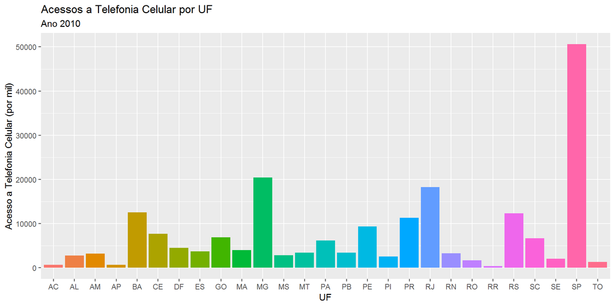

## Análise do tema

## Análise de correlação - PIB

Começamos nossas análises pelo PIB, juntando as tabelas de SMP e PIB:

```r
base_smp_pib <- acessos_smp %>%
  left_join(pib_pop, by= "UF") %>%
  select(UF, SMP2010, PIB2010, POP2010)
head(base_smp_pib)
```

```
##   UF   SMP2010    PIB2010   POP2010
## 1 AC   658.802   8342.356   732.793
## 2 AL  2798.956  27133.038  3120.922
## 3 AM  3210.296  60877.123  3480.937
## 4 AP   656.662   8237.795   668.689
## 5 BA 12561.991 154419.547 14021.432
## 6 CE  7734.210  79336.299  8448.055
```

## Análise de correlação - PIB

```r
summary(base_smp_pib)
```

```
##        UF        SMP2010         PIB2010           POP2010
##  AC     : 1   Min.   :  385   Min.   :   6639   Min.   :  451.2
##  AL     : 1   1st Qu.: 2693   1st Qu.:  26769   1st Qu.: 2506.2
##  AM     : 1   Median : 3749   Median :  60877   Median : 3512.7
##  AP     : 1   Mean   : 7516   Mean   : 143920   Mean   : 7064.7
##  BA     : 1   3rd Qu.: 8553   3rd Qu.: 148950   3rd Qu.: 8622.0
##  CE     : 1   Max.   :50590   Max.   :1294696   Max.   :41252.2
##  (Other):21
```

## Análise de correlação - PIB

```r
library(broom)
cor.test(x= base_smp_pib[["SMP2010"]], y= base_smp_pib[["PIB2010"]])
```

```
##
##  Pearson's product-moment correlation
##
## data:  base_smp_pib[["SMP2010"]] and base_smp_pib[["PIB2010"]]
## t = 25.103, df = 25, p-value < 2.2e-16
## alternative hypothesis: true correlation is not equal to 0
## 95 percent confidence interval:
##  0.9576202 0.9912991
## sample estimates:
##       cor
## 0.9807356
```

Podemos perceber que o coeficiente é extremamente alto (r = 0,98), indicando que há uma correlação muito alta entre o PIB e a quantidade de linhas de telefonia celular.

## Análise de correlação - PIB

```r
mrls <- base_smp_pib %>%
  lm(PIB2010 ~ SMP2010, data = .)
mrls
```

```
##
## Call:
## lm(formula = PIB2010 ~ SMP2010, data = .)
##
## Coefficients:
## (Intercept)      SMP2010
##   -42329.22        24.78
```

Y = -42329,22 + 24,78 * x

## Análise de correlação - PIB

[figure not shown]

## Análise de correlação - IDH

Para a análise de correlação com o IDH, seguiremos os mesmos passos da outra variável estudada:

```r
base_smp_idh <- acessos_smp %>%
  left_join(idh, by= "UF") %>%
  select(UF, SMP2010, IDH2010) %>%
  mutate(IDH2010 = as.numeric(gsub(",", ".", as.character(IDH2010))))
head(base_smp_idh)
```

```
##   UF   SMP2010 IDH2010
## 1 AC   658.802   0.663
## 2 AL  2798.956   0.631
## 3 AM  3210.296   0.674
## 4 AP   656.662   0.708
## 5 BA 12561.991   0.660
## 6 CE  7734.210   0.682
```

## Análise de correlação - IDH

```r
summary(base_smp_idh)
```

```
##       UF               SMP2010         IDH2010
##  Length:27          Min.   :  385   Min.   :0.6310
##  Class :character   1st Qu.: 2693   1st Qu.:0.6640
##  Mode  :character   Median : 3749   Median :0.6990
##                     Mean   : 7516   Mean   :0.7045
##                     3rd Qu.: 8553   3rd Qu.:0.7375
##                     Max.   :50590   Max.   :0.8240
```

## Análise de correlação - IDH

```r
cor.test(x= base_smp_idh[["SMP2010"]], y= base_smp_idh[["IDH2010"]])
```

```
##
##  Pearson's product-moment correlation
##
## data:  base_smp_idh[["SMP2010"]] and base_smp_idh[["IDH2010"]]
## t = 2.4014, df = 25, p-value = 0.02409
## alternative hypothesis: true correlation is not equal to 0
## 95 percent confidence interval:
##  0.06334403 0.69809805
## sample estimates:
##       cor
## 0.4329365
```

Considerando a fraca correlação apresentada (r = 0,432), é possível afirmar que o IDH possui pouca relação com a aquisição de linhas celulares.

## Análise de correlação - IDH

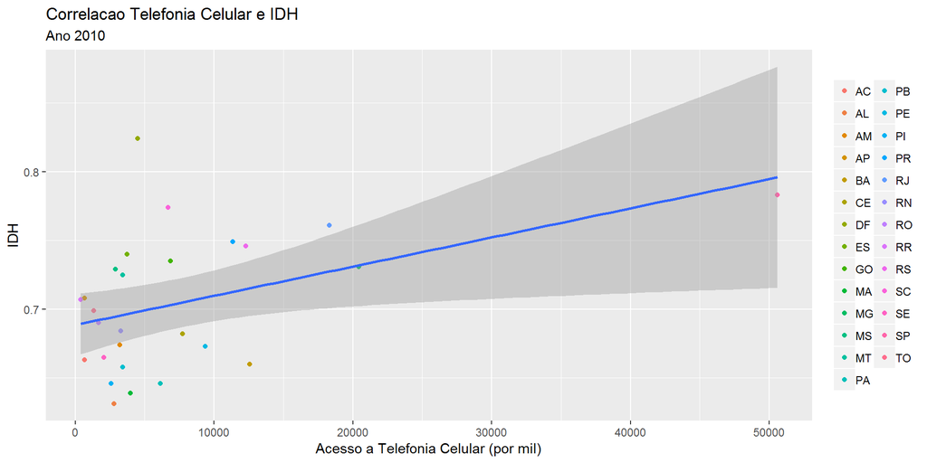

## Conclusão

## Interpretação dos resultados - SMP e PIB

- Os resultados em relação ao PIB mostraram que a correlação é quase perfeita, o que significa que há uma associação muito forte entre as duas variáveis;
- Além disso, o coeficiente é positivo, conforme indicado pela reta de regressão ascendente, o que significa que ambas as variáveis tendem a aumentar ou diminuir em conjunto;
- Contudo, não se pode concluir que as mudanças em uma variável causam mudanças em outra variável com base apenas na correlação. Somente experimentos adequadamente controlados permitem que se determine se uma relação é causal.

## Interpretação dos resultados - SMP e IDH

- No cálculo da correlação com o IDH foi observado que há uma relação positiva fraca entre as variáveis;
- Um coeficiente de correlação de Pearson baixo não significa que não existe nenhuma relação entre as variáveis, pois podem ter uma relação não linear;
- Como a intensidade da correlação linear não foi muito significativa, o trabalho apenas se propôs a demonstrar os resultados, sem construir modelos que podem gerar controvérsia.

## Conclusão

- É importante ressaltar que a correlação é uma medida que não é resistente ao centro, ou seja, como o seu cálculo depende da média das variáveis, ela é muito sensível a observações que estão em posições extremas;
- Por fim, salientamos que é muito comum que variáveis ocultas tenham influência neste tipo de trabalho exploratório. É necessário um trabalho mais aprofundado sobre o assunto, bem como do contexto histórico do período analisado para conseguir análises mais informativas.